# GOV321

Day 3: Analyzing Experiments in R

DIGSSCORE LAB

12.02.2025

So far, you have learned various methods to examine relationships between variables, from summary tables and visualizations to statistical techniques such as correlation and linear regression. The primary goal of these analyses has been to determine whether a relationship exists between two variables. However, none of the methods we have used so far allow us to establish the direction of the relationship—that is, whether one variable actually causes changes in the other.

As you will learn in this session, establishing causality is not simply a matter of applying more advanced statistical tools. Instead, it depends largely on how the data was generated. In this session, we will explore how a survey experiment can be used to establish causal relationships by randomly assigning treatments to respondents. Furthermore, we will see that we can analyze the experiment using familiar tools, such as linear regression, to quantify the impact of the treatment and assess its statistical significance.

### What Does It Mean for a Relationship to Be Causal?

A relationship is considered causal if changes in one variable directly lead to changes in another. We refer to the variable that is deliberately manipulated as the treatment variable, while the variable that responds to this change is the outcome variable.

In mathematical notation, we typically represent the treatment variable as X and the outcome variable as Y. A causal relationship between them is expressed visually as:

$$X → Y$$

When estimating the causal effect of X on Y, we aim to quantify how much a change in the treatment variable X influences the outcome variable Y.

However, estimating causal effects is challenging because several factors can obscure causal relationships. Foe example, a third variable might influence both X and Y (this is called a confounding variable), or the relationship might go the other way (Y causes X, known as reverse causality).

Consider the relationship between left-right self-placement and immigration attitudes, which we examined in the previous session. We found that people who identify as right-wing tend to be more skeptical of immigration. However, we cannot conclude, on the basis of the analysis we conducted, that right-wing ideology *causes* anti-immigration attitudes. Several alternative explanations could account for the observed relationship:

- **Confounding:** Both right-wing ideology and immigration skepticism may be influenced by a third variable. For instance, economic insecurity or national identity concerns could simultaneously shape both ideological self-placement and immigration attitudes, creating a spurious correlation.
- **Reverse causality:** It might be that immigration skepticism leads people to identify as right-wing, rather than the other way around. People who become concerned about immigration may adjust their ideological self-placement accordingly, aligning with political movements that reflect their views.

These challenges make it difficult to determine **true causal effects** in observational data. So how can we get around them?

### **The Potential Outcomes Framework: A Thought Experiment for Causality**

To isolate the causal effect of X on Y, we ideally want to observe how the same individual’s outcome would change under different conditions.

Imagine a person’s immigration attitude (Y) depends on their ideological orientation (X). In a perfect world, we would compare:

1. The **outcome (Y) when the person is right-wing (X = 1)**
2. The **outcome (Y) when the same person is left-wing (X = 0)**

If we could observe both, calculating the causal effect would be trivial We would simply find the difference between the outcome under treatment and the outcome absent treatment. That is:

$$Causal Effect = Y(X = 1) - Y(X = 0)$$

Unfortunately, in reality, we cannot observe both potential outcomes for the same individual. A person either identifies as right-wing or left-wing, but not both at the same time. *This is the fundamental problem of causal inference.*

### **Using Experiments to Solve the Causality Problem**

Since we cannot observe both potential outcomes for the same individual, we use randomized experiments to simulate this comparison across individuals. The key idea is random assignment:

- If we randomly assign individuals to different conditions (e.g., right-wing vs. left-wing identity), then on average, the only difference between groups should be the treatment itself.
- This ensures that any observed difference in the outcome (Y) can be attributed to the treatment (X) rather than confounding factors.

However, ideology as an experimental treatment is not a practical example. Manipulating an individual’s ideological beliefs in a controlled experiment is both difficult and ethically questionable. Instead, we will shift our focus to a more realistic and testable example—how exposure to different types of information or framing affects opinions and behavior.

### Survey Experiments: A Practical Approach

A survey experiment is a type of randomized experiment embedded within a survey. It allows researchers to randomly assign different versions of text, images, or arguments (treatments) to respondents and measure how these variations influence their responses to follow-up questions (outcomes).

Survey experiments are particularly effective for studying how people react to different messages, arguments, or frames, making them ideal for examining how persuasion, misinformation, or policy framing shape public opinion.

In this session, we will analyze a real-world example: an experiment examining how different appeals influence people’s willingness to take vaccines.

### Example: Vaccine Appeal Experiment

To do this, the study examined respondents willingness to take a vaccine in response to a hypothetical vaccine disease scenario, after having been randomly subjected to one of three conditions:

1. **Control Group** – Received a neutral message about a hypothetical infectious disease.
2. **Collective Benefit Treatment** – Received an additional message emphasizing how vaccination protects vulnerable individuals in society.
3. **Self-Interest Treatment** – Received an additional message emphasizing how vaccination protects the individual themselves.

### **Experimental Design**

All respondents were first presented with the following baseline scenario:

*“Imagine that a new infectious disease has arisen in the world and that it is on its way to Norway. Those who are infected get flu-like symptoms, but usually recover completely. A few deaths have been recorded due to the virus, and there is concern that it might mutate and become dangerous for many more people. A vaccine against the disease has been developed, but it has not been fully tested with regard to side effects.”*

Respondents in the control group received only this text, and no further appeal. Those assigned to the treatment groups were given the same text as the control group, but with an additional sentence that framed the benefits of vaccination in **either collective** or **self-serving terms**.

**Collective Benefit Treatment:** *“There will always be part of the population that is not vaccinated due to their young age, allergies, or poor health. This group is entirely dependent on most of the population being vaccinated to prevent infection.”*

**Self-Interest Treatment:** *“The vaccine stimulates your body to rapidly mobilize against the disease, ensuring that you stay healthy.”*

### **Outcome Variable: Likelihood of Taking the Vaccine**

After reading the text, respondents were asked:

“How likely is it that you would take the vaccine in such a situation?”

They could select one of the following response options:

1. Not likely at all
2. Slightly likely
3. Somewhat likely
4. Likely
5. Very likely

## **Analysis**

The data from the experiment is stored in the file `ncp_vax.RData`. Let’s load it up!

```r
load("ncp_vax.RData")
```

As always, we begin by having a look at the data structure using `str()`.

```r
str(ncp_vax)
```

```
## tibble [1,160 × 5] (S3: tbl_df/tbl/data.frame)
##  $ vax_att  : num [1:1160] 4 5 4 5 4 2 2 3 4 5 ...
##  $ gender   : chr [1:1160] "female" "female" "female" "male" ...
##  $ education: chr [1:1160] "University/College" "Upper_secondary" "Upper_secondary" "Upper_secondary" ...
##  $ cohort   : chr [1:1160] "1960-1989" "after_1989" "1960-1989" "1960-1989" ...
##  $ treatment: chr [1:1160] "collective" "self_interest" "self_interest" "collective" ...
```

So we have 1,160 respondents and two key variables:

- The **outcome variable** (`Y`) is `vax_att`, which measures vaccine attitudes.
- The **treatment variable** (`X`) is `treatment`, which indicates which experimental condition a respondent was assigned to.

To better understand the distribution of respondents across treatment groups, we can use the `table()` function:

```r
table(ncp_vax$treatment)
```

```
##
##    collective       control self_interest
##           376           383           401
```

Since assignment to treatment groups is random, we expect the groups to be roughly equal in size. However, due to random variation, some groups may have slightly more or fewer respondents than others.

The randomization should have ensured that the individuals who received the different treatment groups should be roughly similar in composition. Let’s use the demographic variables gender, education and birth cohort for a quick check.

```r
table(ncp_vax$gender, ncp_vax$treatment)
```

```
##
##          collective control self_interest
##   female        188     192           201
##   male          188     191           200
```

```r
table(ncp_vax$cohort, ncp_vax$treatment)
```

```
##
##               collective control self_interest
##   1960-1989          185     175           185
##   after_1989          24      25            19
##   before_1960        167     183           197
```

```r
table(ncp_vax$education, ncp_vax$treatment)
```

```
##
##                      collective control self_interest
##   Elementary                 26      32            30
##   University/College        224     209           242
##   Upper_secondary           111     130           117
```

As expected, the treatment groups are roughly similar in composition. While there are some minor discrepancies in the number of respondents assigned to each group, these differences are due to random variation rather than systematic bias. Because the assignment process was randomized, any observed differences in group sizes are simply the result of chance rather than an underlying pattern that could distort the experiment’s findings.

### Analyzing the Experiment: Difference in Means

Now that we have confirmed that the treatment groups are roughly balanced, we can proceed with analyzing the effect of the experimental intervention on vaccine attitudes. A simple and effective way to do this is by comparing the mean outcome (vaccine attitudes) across the three groups. This method, known as the **difference in means**, allows us to see whether exposure to different vaccine messages led to differences in willingness to take the vaccine.

In the first session, we learned how to subset the dataset based on a specific condition and calculate the mean of a variable within that subset using the `mean()` function. We can now apply this technique to examine the average willingness to take the vaccine for respondents in each of the treatment groups.

To do this, we filter the dataset by treatment group and calculate the mean of `vax_att` for each group separately:

```r
mean(ncp_vax$vax_att[ncp_vax$treatment == "control"]) # Calculates the mean of the control group
```

```
## [1] 2.626632
```

```r
mean(ncp_vax$vax_att[ncp_vax$treatment == "self_interest"]) # Calculates the mean of the self-interest treatment
```

```
## [1] 2.897756
```

```r
mean(ncp_vax$vax_att[ncp_vax$treatment == "collective"]) # Calculates the mean of the collective treatment
```

```
## [1] 3.476064
```

Recall that higher values of `vax_att` indicate greater willingness to take the vaccine. The mean willingness is higher in both treatment groups than in the control group, with the highest values observed among those who received the collective benefit treatment.

#### Assessing Statistical Significance with a t-test

While these differences in means suggest that the treatment messages may have influenced vaccine attitudes, we need to determine whether these differences are statistically significant—that is, whether they are likely due to the treatment rather than random chance. To do this, we can use a **t-test**. (Note: Another similar test is **z-test** which is used when the population standard deviation is known. However as we do not know the population standard deviation, we use **t-test** in this case).

A t-test is a statistical test that compares the means of two groups and evaluates whether the observed difference is greater than what we would expect due to random variation alone. If the difference is small and within the range of natural fluctuations, it is unlikely to be meaningful. However, if the difference is large relative to the variability in the data, we may infer that the treatment had an effect.

By convention, a result is considered statistically significant if the **p-value** from the t-test is below 0.05. This means that there is less than a 5% probability that the observed difference occurred by chance alone. If the p-value is below this threshold, we have strong evidence that the treatment had an impact on vaccine willingness. If it is above 0.05, we cannot confidently rule out the possibility that the observed difference is due to random variation.

We conduct independent sample t-tests to compare each treatment group to the control group using the `t.test()` function:

```r
t.test(ncp_vax$vax_att[ncp_vax$treatment == "self_interest"],
       ncp_vax$vax_att[ncp_vax$treatment == "control"])
```

```
##
##  Welch Two Sample t-test
##
## data:  ncp_vax$vax_att[ncp_vax$treatment == "self_interest"] and ncp_vax$vax_att[ncp_vax$treatment == "control"]
## t = 3.3789, df = 780.51, p-value = 0.000764
## alternative hypothesis: true difference in means is not equal to 0
## 95 percent confidence interval:
##  0.1136092 0.4286383
## sample estimates:
## mean of x mean of y
##  2.897756  2.626632
```

```r
t.test(ncp_vax$vax_att[ncp_vax$treatment == "collective"],
       ncp_vax$vax_att[ncp_vax$treatment == "control"])
```

```
##
##  Welch Two Sample t-test
##
## data:  ncp_vax$vax_att[ncp_vax$treatment == "collective"] and ncp_vax$vax_att[ncp_vax$treatment == "control"]
## t = 10.362, df = 747.13, p-value < 2.2e-16
## alternative hypothesis: true difference in means is not equal to 0
## 95 percent confidence interval:
##  0.688508 1.010356
## sample estimates:
## mean of x mean of y
##  3.476064  2.626632
```

Both our treatments have a statistically significant effect on the willingness to take the vaccine. Often, we want to know the magnitude of this effect, known as the average treatment effect. To compute it, we simply subtract the average outcome of the control group from the average outcome of the treatment group:

```r
# Calculates the average treatment effect of the self-interest treatment:
ate1=mean(ncp_vax$vax_att[ncp_vax$treatment == "self_interest"]) - mean(ncp_vax$vax_att[ncp_vax$treatment == "control"])

# Calculates the average treatment effect of the collective treatment:
ate2=mean(ncp_vax$vax_att[ncp_vax$treatment == "collective"])- mean(ncp_vax$vax_att[ncp_vax$treatment == "control"])

ate1
```

```
## [1] 0.2711238
```

```r
ate2
```

```
## [1] 0.849432
```

In conclusion, both self-interest and collective benefit appeals increase people’s willingness to take vaccines, but the collective appeals are most effective.

### **Visualizing Group Means**

One way to visualize average treatment effects is to simply plot the average vaccine willingness for each group, rather than the estimated treatment effects. This provides a clear visual representation of the baseline level in the control group and how much it differs from the treatment groups.

The `plotmeans()` function allows us to plot the group means along with their confidence intervals, making it easy to compare the overall differences.

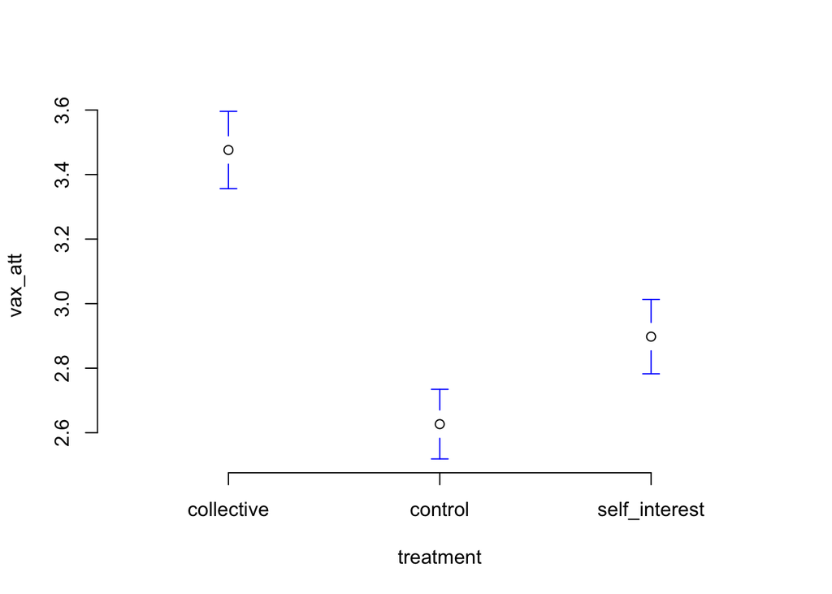

```r
plotmeans(vax_att ~ treatment, data = ncp_vax, frame = F, connect = F,
          n.label=F, mean.labels = F)
```

### **Visualizing ATE**

You can also plot the ATE and the confidence intervals of the ATE directly. We have already calculated the two ATEs `ate1` and `ate2`. You need to calculate the standard error of two average treatment effects.

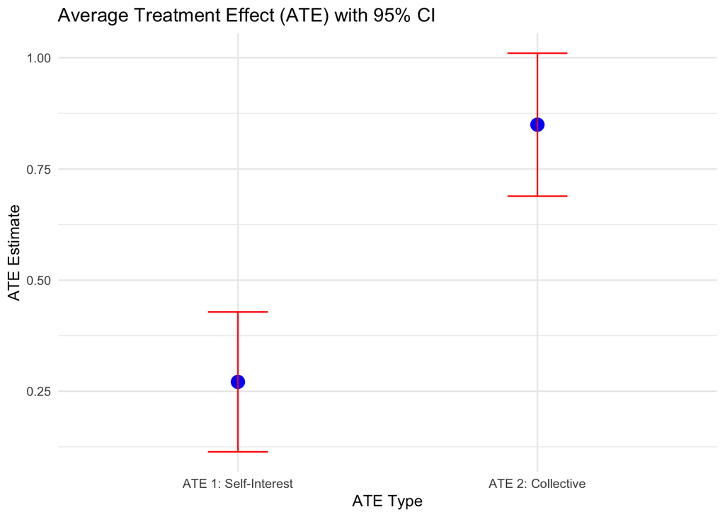

```r
# calculate the standard error of treatment and control
se_treatment1 <- sd(ncp_vax$vax_att[ncp_vax$treatment == "self_interest"])/sqrt(length(ncp_vax$vax_att[ncp_vax$treatment == "self_interest"]))

se_treatment2 <- sd(ncp_vax$vax_att[ncp_vax$treatment == "collective"]) / sqrt(length(ncp_vax$vax_att[ncp_vax$treatment == "collective"]))

se_control <- sd(ncp_vax$vax_att[ncp_vax$treatment == "control"]) / sqrt(length(ncp_vax$vax_att[ncp_vax$treatment == "control"]))

# standard errors of the two average treatment effects
se_ate1 <- sqrt(se_treatment1^2 + se_control^2)
se_ate2 <- sqrt(se_treatment2^2 + se_control^2)

# put everything in a dataframe
ate_df <- data.frame(
  ATE_Type = c("ATE 1: Self-Interest", "ATE 2: Collective"),
  Estimate = c(ate1, ate2),
  Lower = c(ate1 - 1.96 * se_ate1, ate2 - 1.96 * se_ate2),
  Upper = c(ate1 + 1.96 * se_ate1, ate2 + 1.96 * se_ate2)
)

# Plot ATE with confidence intervals
ggplot(ate_df, aes(x = ATE_Type, y = Estimate)) +
  geom_point(size = 4, color = "blue") +
  geom_errorbar(aes(ymin = Lower, ymax = Upper), width = 0.2, color = "red") +
  labs(title = "Average Treatment Effect (ATE) with 95% CI",
       x = "ATE Type",
       y = "ATE Estimate") +
  theme_minimal()
```